# Introduction to Engineering Statistics and R

Engineering Statistics (IMSE 4410) Spring 2015. Copyright 2013-2015 by Timothy Middelkoop License CC by SA 3.0

## Week 2.

### Sample Mean (6-1)

Simple descriptions of data.

```r
x <- c(12.6,12.9,13.4,12.3,13.6,13.5,12.6,13.1)
# Verify the size of the data.
length(x)
```

```
## [1] 8
```

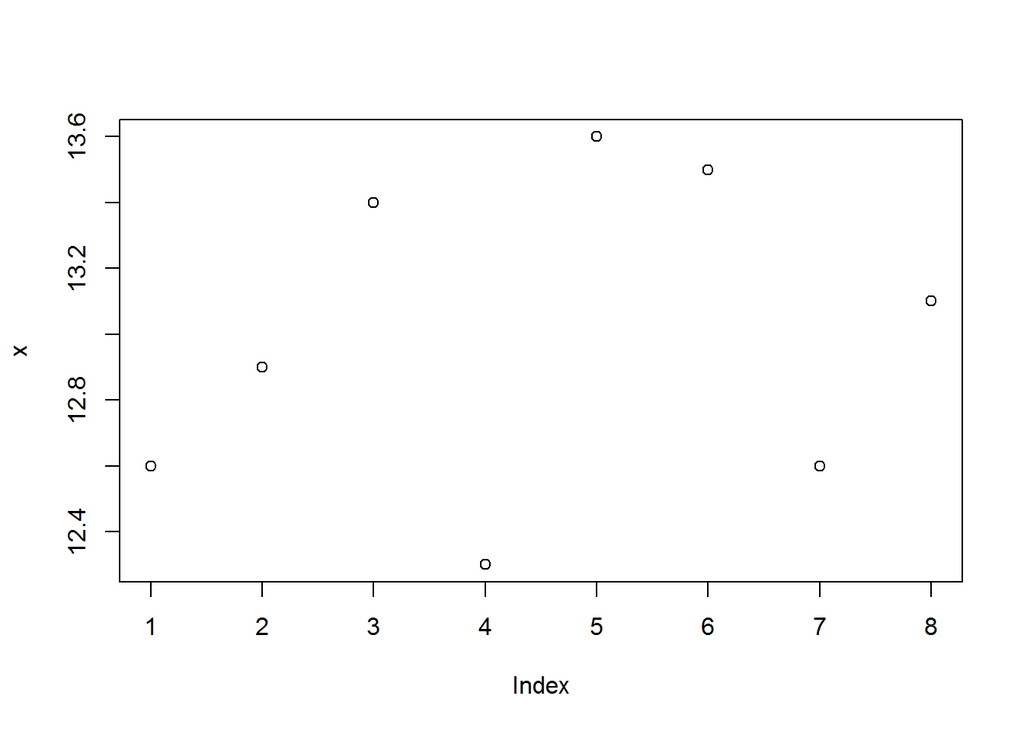

```r
# View the data to get a feel of it.
plot(x)
```

```r
# Verify the analisys.
sum(x)
```

```
## [1] 104
```

```r
sum(x)/length(x)
```

```
## [1] 13
```

```r
# Do it the R way.
mean(x)
```

```
## [1] 13
```

This the sample mean, which is different from the population mean!

What is the population mean? Can we estimate this from the sample mean? It turns out Yes.

$\mu=\sum_{i=1}^N x_i$

mu=sum(xi)/N

### Sample Variance (6-1)

What’s this?

Sample Variance is defined as. Note the Sample and the s^2.

$s^2 = {\sum_{i=1}^n (x_i-\bar x)^2 \over n-1}$

s2=sum((xi-xb)^2)/(n-1)

Calculation:

```r
x
```

```
## [1] 12.6 12.9 13.4 12.3 13.6 13.5 12.6 13.1
```

```r
xb <- mean(x) ; xb
```

```
## [1] 13
```

```r
# compute and verify
x-xb
```

```
## [1] -0.4 -0.1  0.4 -0.7  0.6  0.5 -0.4  0.1
```

```r
# Test your knoledge
sum(x-xb)
```

```
## [1] 0
```

```r
# sqared, note the extra brackets.
sum((x-xb)^2)
```

```
## [1] 1.6
```

```r
# this is why...
sum(x-xb)^2
```

```
## [1] 0
```

```r
# OH.

# Keep this around
n <- length(x) ; n
```

```
## [1] 8
```

```r
# skip a step
s2 <- sum((x-xb)^2)/(n-1) ; s2
```

```
## [1] 0.2285714
```

```r
## 0.2285714

## note the similarity between our equation above and what we just did.

# We will not be using the "short" hand calculation way in this class.

## sample standard deviation.
s <- sqrt(s2) ; s
```

```
## [1] 0.4780914
```

```r
## 0.4780914

# Verify with text.

# Verfy manual
# ?sd

# The R Way
sd(x)
```

```
## [1] 0.4780914
```

### Population Variance (6-1)

Population Variance and Sample variance are NOT this same.

Population Variance: $\sigma^2 = {\sum_{i=1}^N (x_i-\bar x)^2 \over N}$

Note the differences, including n.

### Degrees of Freedom. (6-1)

The term (n-1) is used in the sample since we use $\bar x$ (xb). This is also because if we use this we would consistently underestimate $s^2$. This is also because of the concept of *degrees of freedom*, we can determine any one term if we remove it (calculate backwards).

### Sample Range.

For completeness the sample range r=max(x)-min(x), which is practically R code and is 1.3.